# Predicting Home Sale Prices in Boston

Evan Cernea and Xiaoxia Dong

November 11, 2017

## Introduction

The purpose of this project is to predict the sale prices of homes in Boston given other, known characteristics about the house. Creating models which can predict home prices is both a public and private sector concern – it helps real estate investors figure out where new markets may be taking off, and allows city governments to target properties which may need a tax reassessment. This is a difficult exercise because there are myriad factors, both internatl and external, which determine how much a buyer pays for a house. A house also may be attractive to a certain income group and unnatrractive to others based on unmeasurable or individual characteristics unmeasurable in big data sets.

## Data Section

### Variable Descriptions, Summary Statistics and Correlation Matrix

We gathered our data using a combination of American Community Survey Data from 2011 to 2015, already-existing variables provided in the data set, and data-mining techniques. For ACS Data, we assigned properties characteristics of their Census Block.

#### Dependent Variable: Sale Price

```
##                  SalePriceSummary
## nbr.val              1337.0000000
## nbr.null                0.0000000
## nbr.na                  0.0000000
## min                200000.0000000
## max               4300000.0000000
## range             4100000.0000000
## sum             843105914.0000000
## median             519500.0000000
## mean               630595.2984293
## SE.mean             12347.4153857
## CI.mean.0.95        24222.4337109
## var          203837237387.1062317
## std.dev            451483.3744305
## coef.var                0.7159637
```

**Description**

- This is how much each property sold for in 2015.

#### Independent Variable: Commute Time

```
##              CommuteSummary
## nbr.val        1339.0000000
## nbr.null          3.0000000
## nbr.na            0.0000000
## min               0.0000000
## max              47.0000000
## range            47.0000000
## sum           43320.0000000
## median           33.0000000
## mean             32.3525019
## SE.mean           0.1204940
## CI.mean.0.95      0.2363777
## var              19.4406720
## std.dev           4.4091577
## coef.var          0.1362849
```

**Description**

- This is the average commute time to work on average in the property’s census block.

#### Independent Variable: Living Area

```
##                    LASummary
## nbr.val         1339.0000000
## nbr.null          13.0000000
## nbr.na             0.0000000
## min                0.0000000
## max             9908.0000000
## range           9908.0000000
## sum          3026253.0000000
## median          2080.0000000
## mean            2260.0843913
## SE.mean           27.7179536
## CI.mean.0.95      54.3753784
## var          1028733.5526635
## std.dev         1014.2650308
## coef.var           0.4487731
```

**Description**

- This is how much livable area comes with each property.

#### Independent Variable: Household Size

```
##                  HHSummary
## nbr.val      1339.00000000
## nbr.null        1.00000000
## nbr.na          0.00000000
## min             0.00000000
## max            12.11040000
## range          12.11040000
## sum          9247.35040000
## median          6.76000000
## mean            6.90616161
## SE.mean         0.05565693
## CI.mean.0.95    0.10918435
## var             4.14781206
## std.dev         2.03661780
## coef.var        0.29489866
```

**Description**

- This is the squared value of how many people live in a house on average in the property’s census block.

#### Independent Variable: Quantile of Price Per Square Foot (1-20)

```
##                  NCSummary
## nbr.val       1337.0000000
## nbr.null         0.0000000
## nbr.na           0.0000000
## min              1.0000000
## max             20.0000000
## range           19.0000000
## sum          14657.0000000
## median          11.0000000
## mean            10.9626028
## SE.mean          0.1498243
## CI.mean.0.95     0.2939165
## var             30.0120735
## std.dev          5.4783276
## coef.var         0.4997287
```

**Description**

- The training data set was split into 20 quantiles based on their per sqft sales price. Then, a number was assigned to houses in each quantile, 1 being the lowest price per square foot and 20 being the highest price per square foot.

#### Correlation Matrix

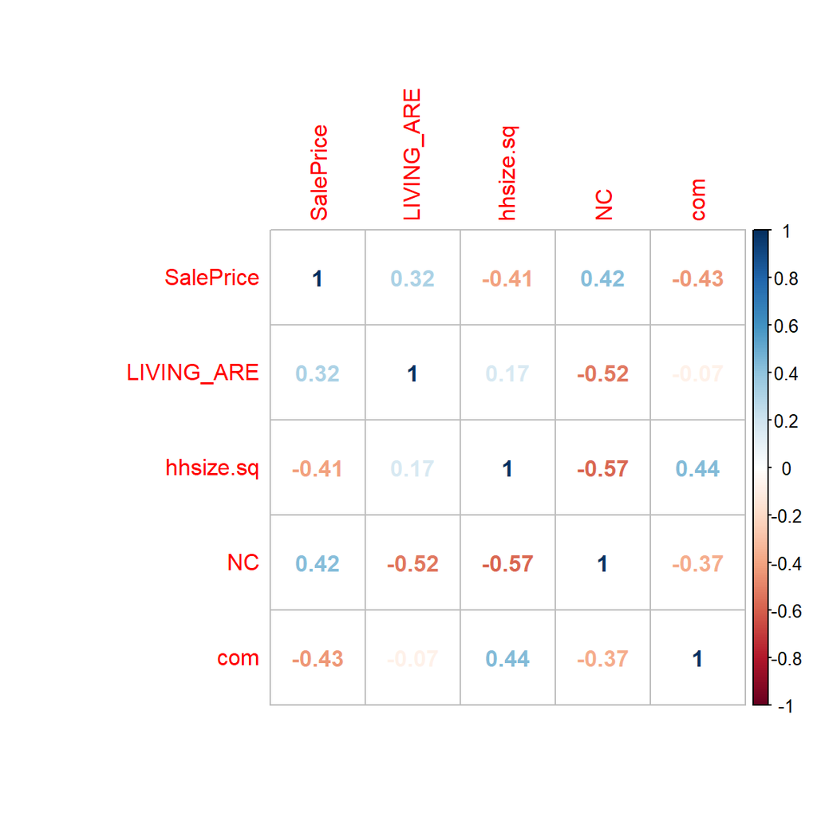

### Map of Variables

[interactive chart not shown]

## Methods

Our guiding philosophy is to consider factors that potential home sellers/buyers and property tax officials would consider when assessing home price. We used three variables to represent the factors that the above mentioned parties are mostly likely to take into consideration when assessing the price of a house. These variables are price for nearby houses, transit availability, and living area.

For transit availability, we took information from the American Community Survey about the average commute time from each census block and applied that to homes which fell in those boundaries.

For price for nearby houses, we splitted the training data set into 20 quantiles based on their per sqft sales price. we then assigned a category to houses in each quantile. We then used selecting by location in GIS to find houses in the testing data that are in the vicinity of houses in each category. This allowed us to assign a category number to the testing data based on the per sqft price of the nearest houses in the training data. For those houses (in testing set) that are in the vicinity of multiple categories, we went on Google map to find out which category would be the most sensible. Given how clustered the per sqft sales prices are, there are many reasons to believe that a house (in the testing set) that falls in a sea of, say, Category 5 houses in training set ($200 - $210/sq ft), is also likely to be a category 5. By doing so, we made use of the spatial autocorrelation of housing prices (although houses in the same category may not be all in the same area).

## Results

### Modeling Results

#### Results 1: In sample model results

```
##
## ===============================================
##                         Dependent variable:
##                     ---------------------------
##                              log_price
## -----------------------------------------------
## NewCategor1                  -0.390**
##                               (0.182)
##
## NewCategor2                   -0.159
##                               (0.181)
##
## NewCategor3                   -0.041
##                               (0.181)
##
## NewCategor4                    0.038
##                               (0.181)
##
## NewCategor5                    0.177
##                               (0.181)
##
## NewCategor6                    0.187
##                               (0.181)
##
## NewCategor7                    0.277
##                               (0.181)
##
## NewCategor8                   0.317*
##                               (0.181)
##
## NewCategor9                   0.340*
##                               (0.181)
##
## NewCategor10                  0.381**
##                               (0.181)
##
## NewCategor11                  0.441**
##                               (0.181)
##
## NewCategor12                 0.499***
```

[output cut: 25 more lines]

```
##
## Commute                      -0.005***
##                               (0.001)
##
## Constant                     12.167***
##                               (0.186)
##
## -----------------------------------------------
## Observations                   1,339
## R2                             0.849
## Adjusted R2                    0.846
## Residual Std. Error      0.180 (df = 1317)
## F Statistic         351.643*** (df = 21; 1317)
## ===============================================
## Note:               *p<0.1; **p<0.05; ***p<0.01
```

#### Results 2: A table for training data

```
##   RSq.training RootMSE.training MAPE.training MAE.training
## 1        0.846           441151          0.11      90700.3
```

#### Results 3: A table for testing data

```
##   RSq.testing RootMSE.testing MAPE.testing MAE.testing
## 1          NA        194157.2        0.104    78342.21
```

#### Results 4: CV on training data

```
## Linear Regression
##
## 1339 samples
##    3 predictor
##
## No pre-processing
## Resampling: Cross-Validated (10 fold)
## Summary of sample sizes: 1204, 1205, 1205, 1206, 1204, 1206, ...
## Resampling results:
##
##   RMSE       Rsquared  MAE
##   0.1847029  0.843261  0.1144113
##
## Tuning parameter 'intercept' was held constant at a value of TRUE
```

#### Results 4.1: Histogram Distribution

```
##   Standard Deviation
## 1         0.03680095
```

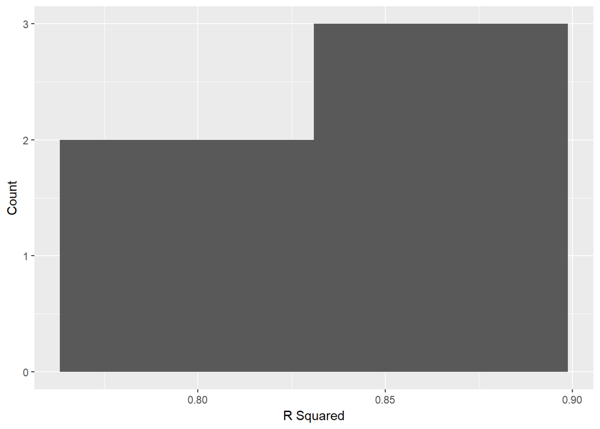

#### Results 5: Residual = f(Observed)

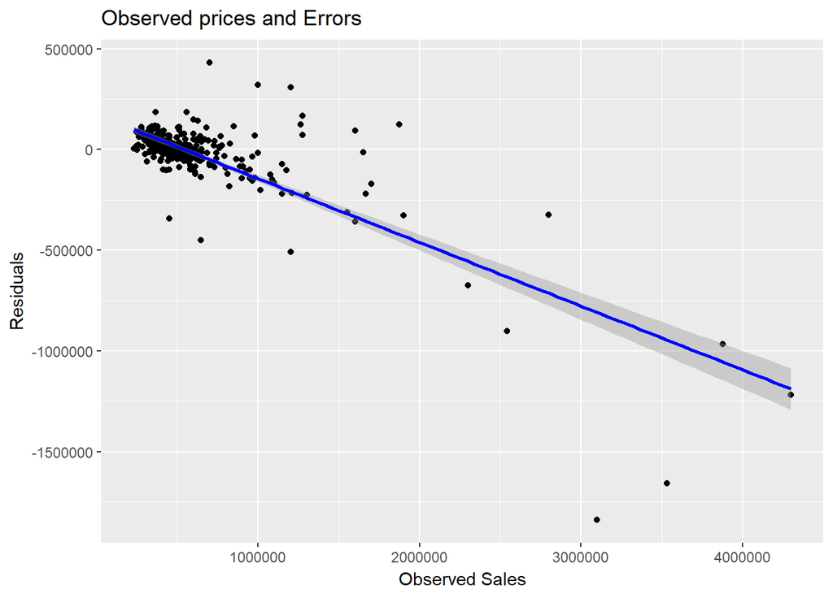

#### Results 6: Residual = f(Predicted)

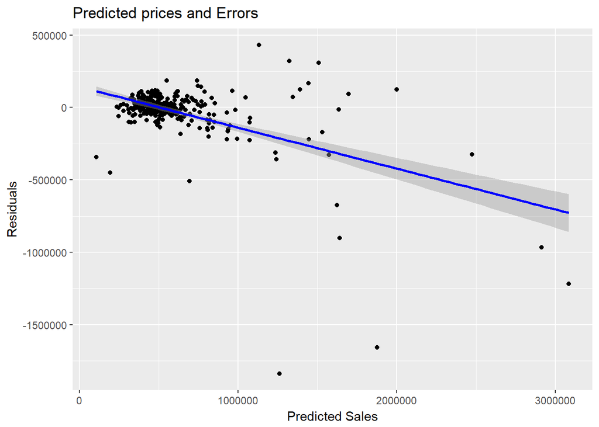

#### Results 7: Residual mapping and Moran’s I

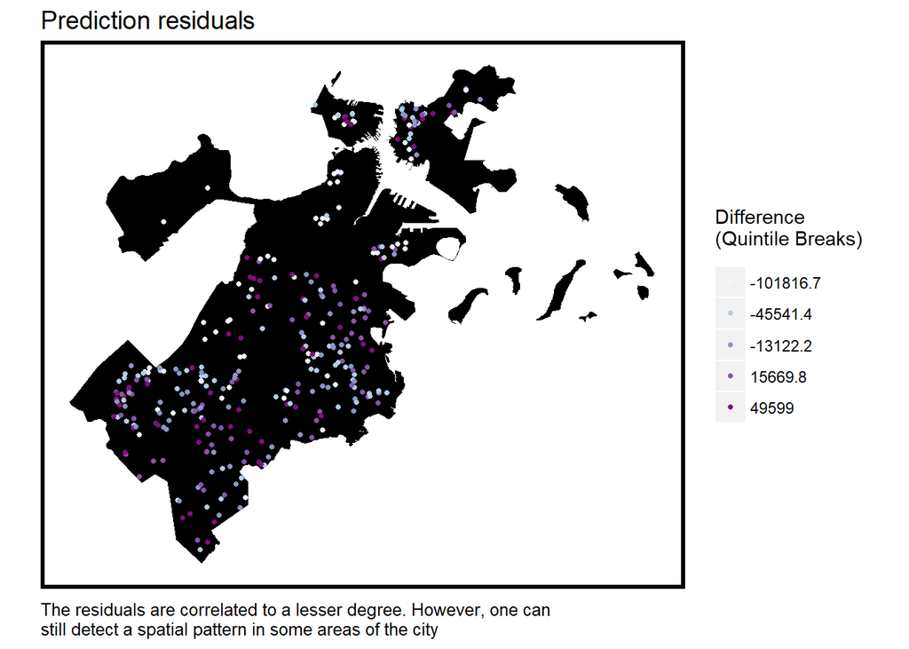

#### Results 7.1: Morans I results

```
##
##  Moran I test under randomisation
##
## data:  reg.testing.df$error
## weights: nb2listw(spatialWeights, style = "W")
##
## Moran I statistic standard deviate = 12.81, p-value <
## 0.00000000000000022
## alternative hypothesis: greater
## sample estimates:
## Moran I statistic       Expectation          Variance
##       0.426139032      -0.003003003       0.001122362
```

#### Results 8: Predicted value map

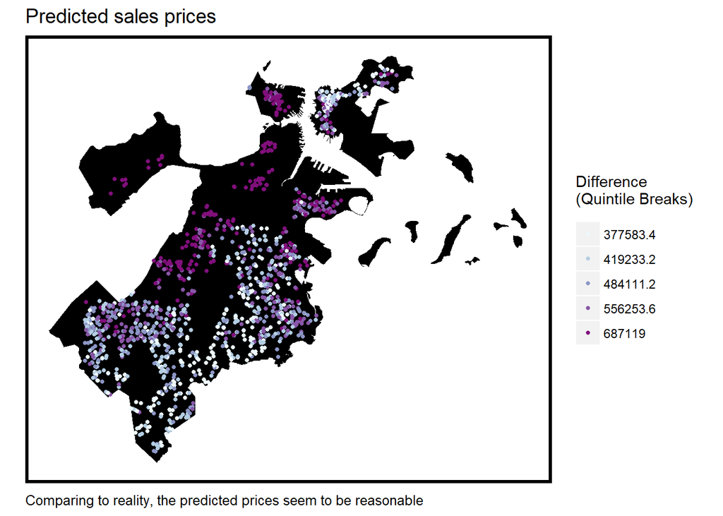

#### Results 9: MAPE by neighborhood

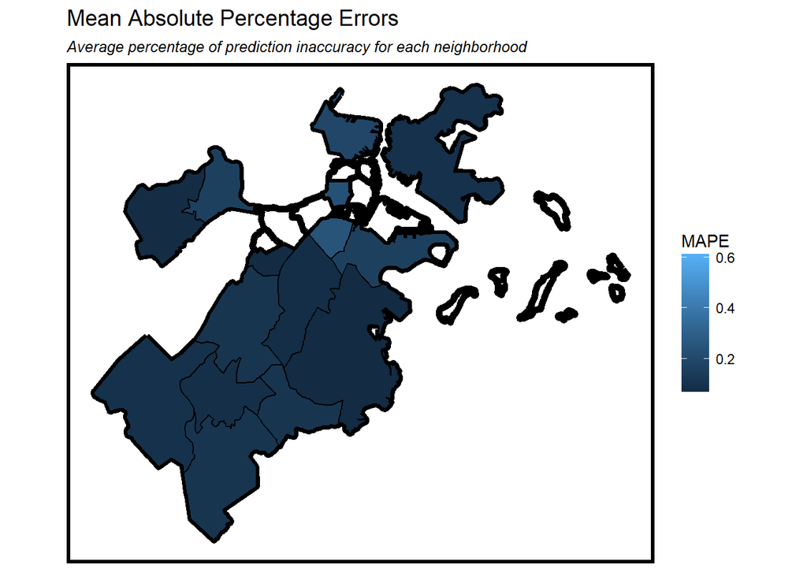

```
##
##       Allston      Back Bay   Bay Village   Beacon Hill      Brighton
##             6             2             1            14             6
##   Charlestown    Dorchester      Downtown   East Boston        Fenway
##            60           307             1           138             2
##     Hyde Park Jamaica Plain      Mattapan  Mission Hill    Roslindale
##           135           103            56            13           126
##       Roxbury  South Boston     South End  West Roxbury
##            57            70            18           211
```

### Extra credit

#### Regression Results by Neighborhood Wealth

##### High Income Neighborhood Results

```
##
## Call:
## lm(formula = log_price ~ NewCategor + LIVING_ARE + Commute +
##     NUM_FLOORS + MedHHInc, data = dat.no.rich)
##
## Residuals:
##      Min       1Q   Median       3Q      Max
## -0.86610 -0.06679 -0.00034  0.06837  0.97793
##
## Coefficients:
##                   Estimate    Std. Error t value             Pr(>|t|)
## (Intercept)  11.8833692549  0.1515090418  78.433 < 0.0000000000000002 ***
## NewCategor1  -0.4290864946  0.1457837053  -2.943             0.003316 **
## NewCategor2  -0.1807326967  0.1455270024  -1.242             0.214533
## NewCategor3  -0.0697454679  0.1455133976  -0.479             0.631817
## NewCategor4   0.0184661387  0.1453945571   0.127             0.898958
## NewCategor5   0.1151503064  0.1453979208   0.792             0.428552
## NewCategor6   0.1700868417  0.1453454123   1.170             0.242166
## NewCategor7   0.2038613198  0.1454943584   1.401             0.161450
## NewCategor8   0.2836443126  0.1454511542   1.950             0.051420 .
## NewCategor9   0.3146328004  0.1454016024   2.164             0.030689 *
## NewCategor10  0.3636835630  0.1455378914   2.499             0.012604 *
## NewCategor11  0.4340948695  0.1456464853   2.980             0.002942 **
## NewCategor12  0.4665385010  0.1457138631   3.202             0.001405 **
## NewCategor13  0.4588768074  0.1457948054   3.147             0.001692 **
## NewCategor14  0.5636929806  0.1458216855   3.866             0.000117 ***
## NewCategor15  0.5975254813  0.1459457530   4.094       0.000045496698 ***
## NewCategor16  0.6766356199  0.1459310659   4.637       0.000003968548 ***
## NewCategor17  0.7303353102  0.1459430073   5.004       0.000000653328 ***
## NewCategor18  0.8720826510  0.1456684907   5.987       0.000000002901 ***
## NewCategor19  1.3163762367  0.1458109056   9.028 < 0.0000000000000002 ***
## LIVING_ARE    0.0003554107  0.0000067105  52.963 < 0.0000000000000002 ***
## Commute      -0.0031472180  0.0011027109  -2.854             0.004398 **
## NUM_FLOORS    0.0837671296  0.0095489491   8.772 < 0.0000000000000002 ***
## MedHHInc      0.0000013086  0.0000002093   6.251       0.000000000583 ***
## ---
## Signif. codes:  0 '***' 0.001 '**' 0.01 '*' 0.05 '.' 0.1 ' ' 1
##
## Residual standard error: 0.1442 on 1091 degrees of freedom
## Multiple R-squared:  0.9138, Adjusted R-squared:  0.912
## F-statistic: 502.7 on 23 and 1091 DF,  p-value: < 0.00000000000000022
```

```
##   RootMSE.rich MAPE.rich MAE.rich
## 1     70913.61     0.086 46711.29
```

##### Low Income Neighborhood Results

```
##
## Call:
## lm(formula = log_price ~ NewCategor + LIVING_ARE + Commute, data = dat.no.poor)
##
## Residuals:
##      Min       1Q   Median       3Q      Max
## -1.10990 -0.06641  0.00738  0.06552  0.94542
##
## Coefficients:
##                  Estimate   Std. Error t value             Pr(>|t|)
## (Intercept)  12.108679457  0.153502643  78.883 < 0.0000000000000002 ***
## NewCategor1  -0.480349724  0.149435821  -3.214             0.001341 **
## NewCategor2  -0.216575521  0.149229596  -1.451             0.146950
## NewCategor3  -0.096285939  0.149141515  -0.646             0.518656
## NewCategor4  -0.002861354  0.149144714  -0.019             0.984697
## NewCategor5   0.102488317  0.149076772   0.687             0.491904
## NewCategor6   0.156124592  0.148945926   1.048             0.294751
## NewCategor7   0.200468080  0.148958059   1.346             0.178611
## NewCategor8   0.281889261  0.148943600   1.893             0.058644 .
## NewCategor9   0.319432405  0.148853863   2.146             0.032070 *
## NewCategor10  0.372012502  0.148865292   2.499             0.012583 *
## NewCategor11  0.430403471  0.148867778   2.891             0.003905 **
## NewCategor12  0.486870117  0.148859631   3.271             0.001102 **
## NewCategor13  0.487220557  0.148856055   3.273             0.001093 **
## NewCategor14  0.580588505  0.148859308   3.900             0.000101 ***
## NewCategor15  0.614038926  0.148865696   4.125        0.00003956677 ***
## NewCategor16  0.685887677  0.148891173   4.607        0.00000451172 ***
## NewCategor17  0.748965016  0.148880173   5.031        0.00000056034 ***
## NewCategor18  0.913942147  0.148902271   6.138        0.00000000112 ***
## NewCategor19  1.404237305  0.149063603   9.420 < 0.0000000000000002 ***
## LIVING_ARE    0.000402708  0.000005526  72.875 < 0.0000000000000002 ***
## Commute      -0.005061198  0.001117179  -4.530        0.00000645351 ***
## ---
## Signif. codes:  0 '***' 0.001 '**' 0.01 '*' 0.05 '.' 0.1 ' ' 1
##
## Residual standard error: 0.1478 on 1247 degrees of freedom
## Multiple R-squared:    0.9,  Adjusted R-squared:  0.8983
## F-statistic: 534.5 on 21 and 1247 DF,  p-value: < 0.00000000000000022
```

```
##   RootMSE.poor MAPE.poor MAE.poor
## 1     81709.12     0.087 48230.15
```

##### Middle Income Neighborhood Results

```
##
## Call:
## lm(formula = log_price ~ NewCategor + LIVING_ARE + Commute +
##     NUM_FLOORS, data = dat.no.mid)
##
## Residuals:
##      Min       1Q   Median       3Q      Max
## -0.90107 -0.06773  0.00542  0.06447  0.97897
##
## Coefficients:
##                  Estimate   Std. Error t value             Pr(>|t|)
## (Intercept)  11.978895339  0.151637820  78.997 < 0.0000000000000002 ***
## NewCategor1  -0.457916078  0.146048680  -3.135             0.001759 **
## NewCategor2  -0.205522612  0.145895879  -1.409             0.159192
## NewCategor3  -0.086628919  0.145801622  -0.594             0.552523
## NewCategor4  -0.001416867  0.145820291  -0.010             0.992249
## NewCategor5   0.107831411  0.145817384   0.739             0.459754
## NewCategor6   0.159366498  0.145643943   1.094             0.274084
## NewCategor7   0.214141505  0.145880176   1.468             0.142393
## NewCategor8   0.292195881  0.145687455   2.006             0.045125 *
## NewCategor9   0.340259745  0.145788956   2.334             0.019769 *
## NewCategor10  0.391437005  0.145695637   2.687             0.007319 **
## NewCategor11  0.454325756  0.145719602   3.118             0.001867 **
## NewCategor12  0.505208883  0.145625704   3.469             0.000541 ***
## NewCategor13  0.521493335  0.145740913   3.578             0.000360 ***
## NewCategor14  0.602259475  0.145677599   4.134   0.0000381664011289 ***
## NewCategor15  0.636515512  0.145637345   4.371   0.0000134957597021 ***
## NewCategor16  0.720178944  0.145658265   4.944   0.0000008757915290 ***
## NewCategor17  0.772775296  0.145616615   5.307   0.0000001333286544 ***
## NewCategor18  0.918427710  0.145602075   6.308   0.0000000004008210 ***
## NewCategor19  1.377411240  0.145816336   9.446 < 0.0000000000000002 ***
## LIVING_ARE    0.000364886  0.000006548  55.729 < 0.0000000000000002 ***
## Commute      -0.003576790  0.001141948  -3.132             0.001778 **
## NUM_FLOORS    0.071351955  0.009280308   7.689   0.0000000000000314 ***
## ---
## Signif. codes:  0 '***' 0.001 '**' 0.01 '*' 0.05 '.' 0.1 ' ' 1
##
## Residual standard error: 0.1445 on 1168 degrees of freedom
## Multiple R-squared:  0.9051, Adjusted R-squared:  0.9033
## F-statistic: 506.4 on 22 and 1168 DF,  p-value: < 0.00000000000000022
```

##### Final Table with All Income Levels

```
##    RootMSE  MAPE      MAE  level
## 1 81709.12 0.087 48230.15   poor
## 2 52352.95 0.099 37742.87 middle
## 3 70913.61 0.086 46711.29   rich
```